# Raster geodata in R; basics of functional programming in R

Author

Ondrej Ledvinka

Published

April 23, 2024

Modified

April 23, 2024

## Lesson prerequisites

As usual, we are working within the R project established during the first lesson; therefore, we use relative paths to files. We also assume that we have some subfolders in the folder related to the project (e.g. for data, geodata, metadata, results, temporary files, etc.). Good internet connection is required because we will load geographical data directly to R using various services or functions of specialized packages.

If possible, we are working with the newest versions of R (currently, R version 4.3.3 (2024-02-29 ucrt) – Angel Food Cake from 2024-02-29) and RStudio (currently, RStudio 2023.12.1+402 Ocean Storm from 2024-01-29).

## Raster geodata in R

There are two main packages for working with raster geodata in R – `terra` (Hijmans, 2024) and `stars` (Pebesma and Bivand, 2023). The package `stars` is developed by the same authors who develop the `sf` package. So, the names of the functions are similar. Since working with the package `stars` is based on arrays and it is somehow difficult for beginners, we exclusively work with the `terra` package and its functions here. `terra` is a successor to the package `raster` which was also accompanied by many functions devoted to retrieving some of the geodata directly from the internet. Currently, `terra` is accompanied by an extra package for this purpose – `geodata` (Hijmans et al., 2023). It is important to note that also a package has been developed to work with `terra` objects (usually the type called *SpatRaster*) in a tidyverse manner – `tidyterra` (Hernangómez, 2023)[^1]. In addition, this package provides functions for plotting the raster layers using the `ggplot2` approach. It is not necessary to have only one-layer SpatRaster objects, but we may also also multiple-layer SpatRaster objects, which allows multiple variables or time series of the same variable in the same objects. SpatRaster objects are very close to lists, so we can manipulate with them in a similar way (e.g. subsetting).

Let us show, how to load raster data from a file on the one hand and how to load them while employing the functions of packages such as `geodata` or `RCzechia` (Lacko, 2023) on the other. Since we do not have any files in our project subfolders, we will first load some data using the R functions, save them to the files and, lastly, load the data from files.

```r
# first, we need to load some of the necessary packages
xfun::pkg_attach("tidyverse",
                 "terra",
                 "tidyterra",
                 "RCzechia", # automatically loads the sf package
                 "geodata",
                 install = T) # only for cases we did not install the packages previously

# let us retrieve a DEM of Czechia using a function from the RCzechia package
czdem1 <- vyskopis(format = "actual")

# observe the header of the object loaded as a SpatRaster
czdem1
```

```
class       : SpatRaster
dimensions  : 2028, 5491, 1  (nrow, ncol, nlyr)
resolution  : 0.001232732, 0.001232732  (x, y)
extent      : 12.09036, 18.85929, 48.55533, 51.05531  (xmin, xmax, ymin, ymax)
coord. ref. : lon/lat WGS 84 (EPSG:4326)
source(s)   : memory
varname     : vyskopis-dem
name        :     Band_1
min value   :   54.05701
max value   : 1561.23718
```

```r
# some functions allow saving to files at the same time
czdem2 <- elevation_30s(country = "CZE",
                        path = "geodata")

# what are the differences?
czdem2
```

```
class       : SpatRaster
dimensions  : 336, 852, 1  (nrow, ncol, nlyr)
resolution  : 0.008333333, 0.008333333  (x, y)
extent      : 11.9, 19, 48.4, 51.2  (xmin, xmax, ymin, ymax)
coord. ref. : lon/lat WGS 84 (EPSG:4326)
source      : CZE_elv_msk.tif
name        : CZE_elv_msk
min value   :          51
max value   :        1524
```

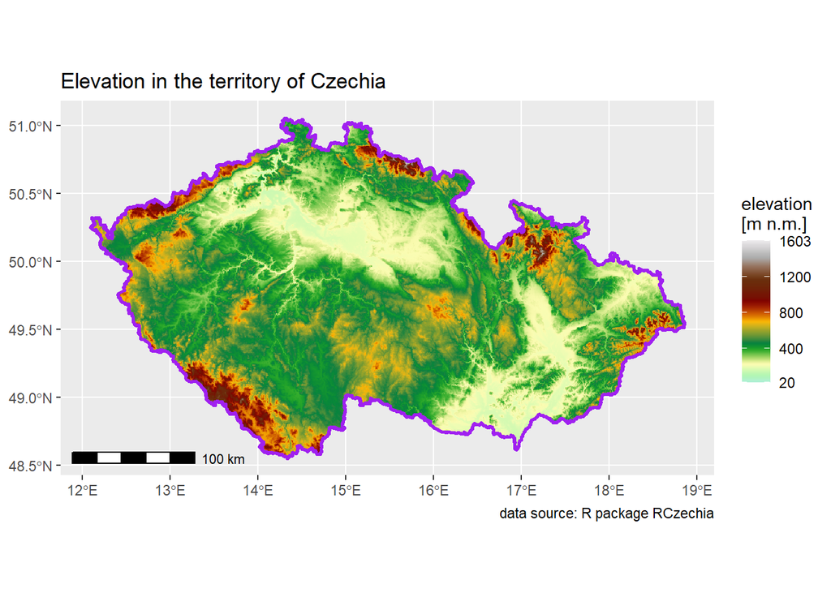

```r
# we can also create a simple static maps using the ggplot2 and tidyterra functions
library(ggspatial) # for adding a scale bar

ggplot() +
  geom_spatraster(data = czdem1) +
  scale_fill_hypso_tint_c(palette = "wiki-schwarzwald-cont",
                          na.value = NA,
                          limits = c(20, 1603),
                          breaks = c(20, 400, 800, 1200, 1603)) +
  labs(fill = "elevation\n[m n.m.]",
       title = "Elevation in the territory of Czechia",
       caption = "data source: R package RCzechia") +
  geom_sf(data = republika(),
          col = "purple",
          fill = NA,
          linewidth = 1) +
  annotation_scale()
```

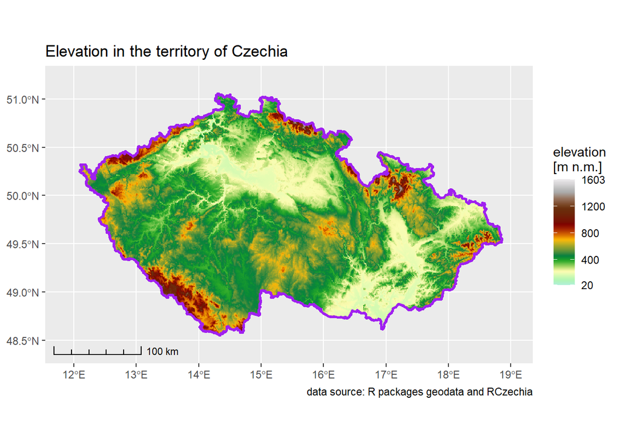

```r
# and with the second DEM as well
ggplot() +
  geom_spatraster(data = czdem2) +
  scale_fill_hypso_tint_c(palette = "wiki-schwarzwald-cont",
                          na.value = NA,
                          limits = c(20, 1603),
                          breaks = c(20, 400, 800, 1200, 1603)) +
  labs(fill = "elevation\n[m n.m.]",
       title = "Elevation in the territory of Czechia",
       caption = "data source: R packages geodata and RCzechia") +
  geom_sf(data = republika(),
          col = "purple",
          fill = NA,
          linewidth = 1) +
  annotation_scale(style = "ticks")
```

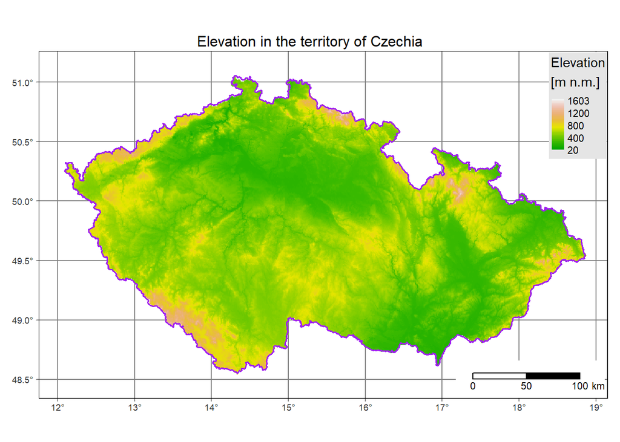

```r
# similarly, we can create maps using the functions of the tmap package
library(tmap)

tm_shape(czdem2) +
  tm_graticules(labels.cardinal = F) +
  tm_raster(palette = terrain.colors(8),
            style = "cont",
            breaks = c(20, 400, 800, 1200, 1603),
            legend.reverse = T,
            title = "Elevation\n[m n.m.]",
            legend.format = list(big.mark = "")) +
  tm_shape(republika()) +
  tm_borders(col = "purple",
             lwd = 1.5) +
  tm_scale_bar(position = c("RIGHT", "BOTTOM"),
               text.size = 0.7,
               breaks = c(0, 50, 100),
               bg.color = "white") +
  tm_layout(legend.position = c("RIGHT", "TOP"),
            legend.bg.color = "grey90",
            main.title = "Elevation in the territory of Czechia",
            main.title.position = "center",
            main.title.size = 1)
```

```r
# we already have czdem2 saved but what to do if we want to save czdem1 as well?
# we need to use the writeRaster() function
# or in case of more layers, we usually save to NetCDF files
# again, by specifying the suffix, the correct driver is chosen
writeRaster(czdem1,
            "geodata/czdem1.tif",
            overwrite = T) # in case the file of the same name already exists

# the function rast() may be used to read raster data from a file
# but the rast() function has more purposes; kindly study the help page
czdem1 <- rast("geodata/czdem1.tif")

czdem1
```

```
class       : SpatRaster
dimensions  : 2028, 5491, 1  (nrow, ncol, nlyr)
resolution  : 0.001232732, 0.001232732  (x, y)
extent      : 12.09036, 18.85929, 48.55533, 51.05531  (xmin, xmax, ymin, ymax)
coord. ref. : lon/lat WGS 84 (EPSG:4326)
source      : czdem1.tif
name        :     Band_1
min value   :   54.05701
max value   : 1561.23718
```